# ISBN: 978-958-5153-36-3-G11-2024-1 Pregunta 16

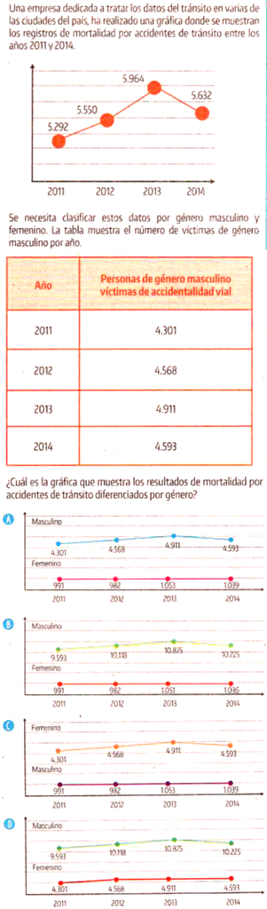

Para determinar cuál es la gráfica que muestra los resultados de mortalidad por accidentes de tránsito diferenciados por género, debemos analizar cada una de las opciones proporcionadas y compararlas con los datos de la tabla.

## Análisis de los datos

Primero, revisemos los datos de la tabla:

| Año | Personas de género masculino víctimas de accidentalidad vial |
| --- | --- |
| 2011 | 4,301 |
| 2012 | 4,568 |
| 2013 | 4,911 |
| 2014 | 4,593 |

## Análisis de las gráficas

Ahora, analicemos cada una de las gráficas proporcionadas:

### Opción A

En esta gráfica, se muestran dos líneas: una para el género masculino y otra para el género femenino. Los valores para el género masculino son:

- 2011: 4,301
- 2012: 4,568
- 2013: 4,911
- 2014: 4,593

Estos valores coinciden exactamente con los datos de la tabla.

### Opción B

Estos valores no coinciden con los datos de la tabla.

### Opción C

En esta gráfica, los valores para el género masculino son:

Estos valores coinciden exactamente con los datos de la tabla, pero la gráfica está invertida (los valores masculinos están en la línea de género femenino y viceversa).

### Opción D

Estos valores no coinciden con los datos de la tabla.

## Conclusión

La gráfica que muestra correctamente los resultados de mortalidad por accidentes de tránsito diferenciados por género es la **Opción A**.

# Análisis de la Pregunta según SABER 11 ICFES

Responderé siguiendo la estructura solicitada:

### Nivel de Desempeño. Puntaje

Nivel 2 (Puntaje 36-50)  
Justificación: El estudiante debe comparar datos de dos variables (género masculino y femenino) presentadas en una misma gráfica.

### Competencia Dominante

- Interpretación y Representación (100%)  
  Justificación: Requiere interpretar datos presentados en diferentes formatos (tabla y gráfica) y comparar su correspondencia.

### Afirmación

Comprende y transforma la información cuantitativa y esquemática presentada en distintos formatos.

### Componente Dominante

Aleatorio (100%)  
Justificación: Involucra análisis de datos estadísticos presentados en gráficas y tablas.

### Aprendizajes

Comparar, usar e interpretar datos que provienen de situaciones reales y traducir entre diferentes representaciones de un conjunto de datos.

### Evidencias

- Lee e interpreta datos en diferentes representaciones (gráficas y tablas)
- Compara diferentes representaciones del mismo conjunto de datos

### Contenidos Matemáticos Curriculares

Estadística - Análisis de datos y gráficas

### ¿Genérico o No Genérico?

No Genérico  
Justificación: Evalúa específicamente competencias matemáticas en el análisis de datos estadísticos.

### Estándar asociado

Interpreta información presentada en tablas y gráficas (pictogramas, gráficas de barras, diagramas de líneas, diagramas circulares).

### ¿Qué evalúa?

La capacidad para:

- Interpretar datos presentados en diferentes formatos
- Comparar representaciones gráficas
- Verificar la coherencia entre datos numéricos y su representación gráfica

### Situaciones o Contextos de la Prueba

Comunitarios o sociales (accidentalidad vial)

### Ejes Axiales Disciplinares

- Bivariadas: Interpretación de gráficas de líneas con dos variables (género masculino y femenino)

### Ampliación de la Respuesta correcta

La opción A es correcta porque:

1. Los valores para género masculino coinciden exactamente con la tabla:
   - 2011: 4,301
   - 2012: 4,568
   - 2013: 4,911
   - 2014: 4,593
2. La gráfica mantiene la escala apropiada
3. La diferenciación por género está correctamente etiquetada
4. Los datos están representados con claridad y precisión

### Justificación de la respuesta correcta

La opción A representa fielmente los datos de la tabla y además muestra la información complementaria del género femenino de manera coherente y clara.

### Motivos de las opciones incorrectas

- Opción B: Presenta valores incorrectos (aproximadamente el doble) para el género masculino
- Opción C: Invierte la representación de los géneros en las líneas
- Opción D: Combina datos incorrectos con una representación invertida